# Cervical organoids in primary cells - mRNA microarray expression analysis

Hilmar Berger

04 November, 2020 18:39:38

```r
rm(list=ls())
library(limma)
library(reshape2)
library(pheatmap)
library(xtable)
library(gplots)
library(impute)
load("../../Data/Preprocessed/Human_micro_array_preprocessed_data.Rdata")

result_folder = "../../Results/Human"
if (!file.exists(result_folder)) dir.create(result_folder, recursive=T)
```

# 1 Data overview

## 1.1 MDS on normalized data

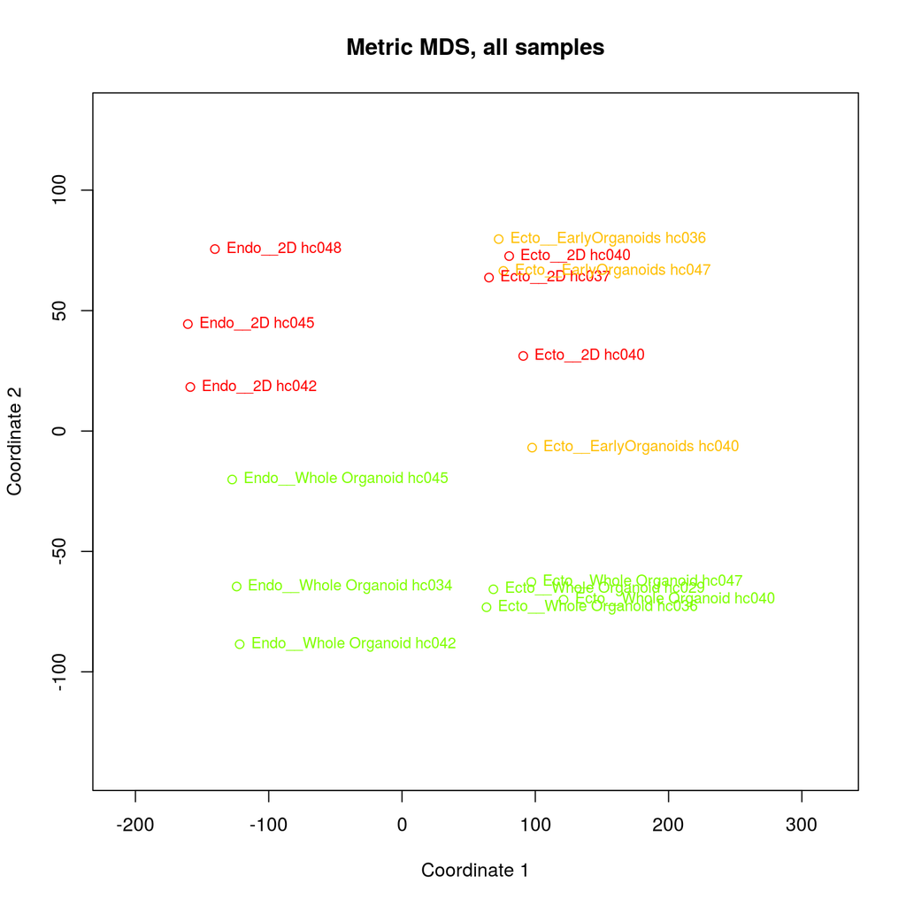

```r
cp = palette(rainbow(8))
data_inp = t(normalized$E)

d <- dist(data_inp) # euclidean distances between the rows
fit <- cmdscale(d,eig=TRUE, k=2) # k is the number of dim

# plot solution
x <- fit$points[,1]
y <- fit$points[,2]
cc = cp[as.numeric(factor(paste(ed[rownames(data_inp),]$Tissue.Status, ed[rownames(data_inp),]$Organoid.Type, ed[rownames(data_inp),]$Infection)))]
plot(x, y, xlab="Coordinate 1", ylab="Coordinate 2", main="Metric MDS, all samples", type="n", ylim=c(min(y)-50, max(y)+50), xlim=c(min(x)-50, max(x)+200))
points(x, y, col=cc)
#text(x,y,labels=ed[rownames(data_inp),]$sample_ID, col=cp[as.numeric(factor(ed[rownames(data_inp),]$Tissue.Status))])
text(x,y,labels=paste(ed[rownames(data_inp),]$ShortName, ed[rownames(data_inp),]$patient_or_mouse_id), col=cc, cex=.8, pos=4)
```

## 1.2 Expression analysis outline

Micro array expression data was preprocessed as described in a separate document.

Expression data will be analysed in the following way:

- For each of the selected comparisons we compare the replicates of the target condition to the correspondig control using LIMMA, producing differential expression statistics for all genes and comparisons.
- Where possible, we try to perfom paired analysis to remove patient effects

All result tables are available as separate Excel files.

## 1.3 Differential expression overview

Comparisons performed:

```r
# remove duplicate and control probes before DE
dups = duplicated.default(normalized$genes$ProbeName)
controls = normalized$genes$ControlType!=0
normalized_unfiltered = normalized
normalized = normalized[!(dups | controls),]

rsd = apply(normalized$E,1,sd,na.rm=T)
rmean = apply(normalized$E,1,mean,na.rm=T)
cofvar = rsd/rmean
low_var_flag =  cofvar < quantile(cofvar,na.rm=T, p=c(0.5))
low_var_flag = rep(F, length(cofvar))

na_cnt_per_row = apply(normalized$E, 1, function(x) sum(is.na(x)))

all_results = list()
all_fits = list()
all_designs = list()
```

```r
# LIMMA user guide 9.5.2
ed$fsk = gsub("\\+FSK", "wFSK",gsub("\\-FSK","woFSK",ed$Forskilin))
TS = factor(make.names(paste(ed$Tissue.Type, ed$Media, ed$fsk, ed$Organoid.Type, sep="_")))
#edata = normalized[!low_var_flag,]
#edata = normalized[na_cnt_per_row<1,]
edata = normalized
design = model.matrix(~ 0 + TS)
colnames(design) = levels(TS)
fit <- lmFit(edata, design)
cont.matrix <- makeContrasts( ecto_early_vs_whole_unpaired = Ecto_M5_wFSK_EarlyOrganoids-Ecto_M5_wFSK_Whole.Organoid,
                              ecto_vs_endo_whole = Ecto_M5_wFSK_Whole.Organoid-Endo_M1.7_woFSK_Whole.Organoid,
                              endo_2D_vs_whole =  Endo_M1.7_woFSK_2D-Endo_M1.7_woFSK_Whole.Organoid,
                              ecto_2D_vs_whole_all = Ecto_M5_wFSK_2D-Ecto_M5_wFSK_Whole.Organoid,
                              levels=design )
fit2 <- contrasts.fit(fit, cont.matrix)
fit2 <- eBayes(fit2)

for (c in colnames(cont.matrix)) {
  res = topTable(fit2, coef=c, adjust="BH", number=nrow(edata))
  all_results[[c]] = res
}

all_fits[["global_model"]] = fit2
all_designs[["global_model"]] = list(samples=rownames(ed), details=list(TS = TS), design = design, global=T, cont.matrix = cont.matrix)
```

### 1.3.1 Volcano plots

For each comparison, the distribution of the fold change (on a log2 scale) and adjusted p-value (on reverse logarithmical scale) is shown in a volcano plot. The red line denotes the FDR cutoff of 0.05.

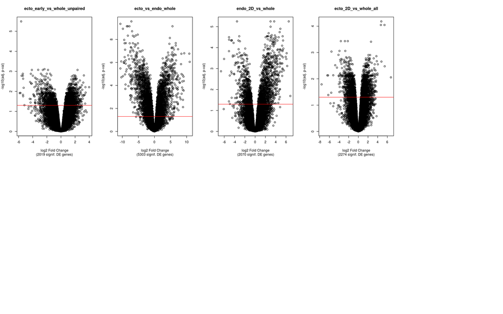

```r
all_target_conditions = names(all_results)
par(mfrow=c(2,5))
for (tc in all_target_conditions) {
  r = all_results[[tc]]
  plot(r$logFC, -log10(r$adj.P.Val),xlab="log2 Fold Change",ylab="-log10(adj. p-val)", ylim=c(0,max(2,max(-log10(r$adj.P.Val),na.rm=T))))
  title(main=tc, sub=paste("(",nrow(subset(r, adj.P.Val < 0.05))," signif. DE genes)",sep="") )
  abline(h=-log10(0.05),col="red")

}
```

### 1.3.2 Overlaps between significantly expressed gene lists

The following table describes the overlap (intersection) of the list of differentially expressed genes between any two comparisons of a target condition to control.  
The Jaccard coefficient defines the ratio of the overlap size to the size of the union of both lists.

```r
# OVERLAPS between clones

#library(VennDiagram)
#v1 = venn.diagram(signif_genes_list, filename="./venn.tiff" )

signif_genes_list = lapply(all_results, function(x) {subset(x,adj.P.Val<0.05)$GeneSymbol})
combinations = combn(names(signif_genes_list),2)
pairwise_intersections = apply(combinations,2, function(x) { intersect(signif_genes_list[[x[1]]], signif_genes_list[[x[2]]])} )
d = as.data.frame(t(combinations))
d$overlap = lapply(pairwise_intersections, length)
comp_names = names(signif_genes_list)
d_mat = matrix(NA, nrow=length(comp_names), ncol=length(comp_names))
colnames(d_mat) = comp_names
rownames(d_mat) = comp_names
tmp = apply(d, 1, function(x) {x = as.vector(unlist(x)); d_mat[ x[1],x[2] ] <<- as.numeric(x[3]); d_mat[ x[2],x[1] ] <<- as.numeric(x[3]) })
rm(tmp)
ll = unlist(lapply(signif_genes_list, length))
for (n in names(ll)) d_mat[n, n] <- ll[n]

totals_m = matrix(rep(ll, times=nrow(d_mat)), nrow(d_mat), ncol(d_mat))
d_mat_prop = d_mat/totals_m

d$pairwise_union_lengths = apply(combinations,2, function(x) { length(union(signif_genes_list[[x[1]]], signif_genes_list[[x[2]]]))} )
d$jaccard_coef = as.numeric(d$overlap)/d$pairwise_union_lengths
```

```r
d_t = d[,c(1,2,3,5)]
colnames(d_t) = c("Condition_1", "Condition_2", "Overlap of DE genes", "Jaccard coefficient")
print.xtable(xtable(d_t,display=c("s","s","s","d","g"), align="|l|l|l|l|l|"), type="html", file="" , include.rownames=F)
```

| Condition_1 | Condition_2 | Overlap of DE genes | Jaccard coefficient |
| --- | --- | --- | --- |
| ecto_early_vs_whole_unpaired | ecto_vs_endo_whole | 572 | 0.099 |
| ecto_early_vs_whole_unpaired | endo_2D_vs_whole | 148 | 0.042 |
| ecto_early_vs_whole_unpaired | ecto_2D_vs_whole_all | 956 | 0.33 |
| ecto_vs_endo_whole | endo_2D_vs_whole | 721 | 0.13 |
| ecto_vs_endo_whole | ecto_2D_vs_whole_all | 643 | 0.11 |
| endo_2D_vs_whole | ecto_2D_vs_whole_all | 227 | 0.061 |

The heatmap below shows the overlap (intersection) of the list of differentially expressed genes between any two comparisons of a target condition to control. The diagonal shows the size of the individual list of differentially expressed genes for a comparison. Values are depicted on a log10 scale (i.e. 2 = overlap of 100 genes and so on).

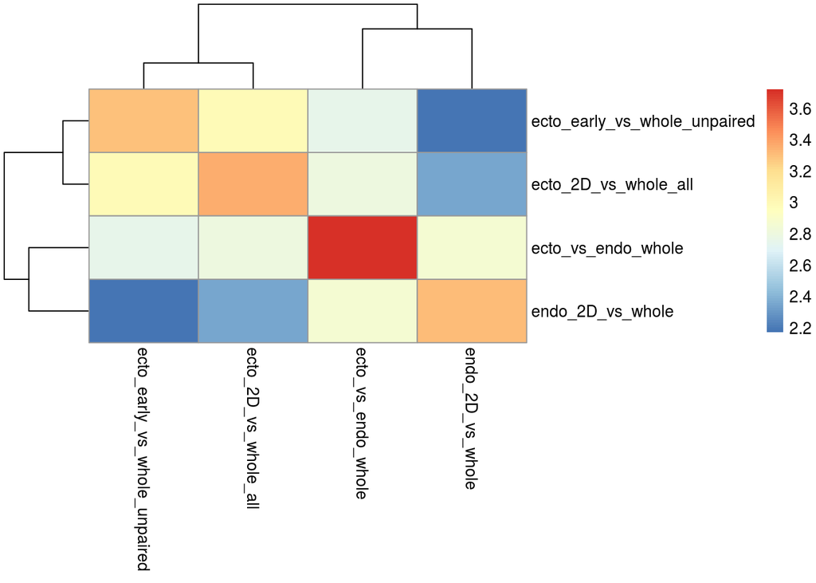

```r
pheatmap(log10(d_mat+1))
```

```r
###############################################################################################################
# Write Result Files
###############################################################################################################

all_DE_results_tmp = list()
for (tc in all_target_conditions) {
  tmp = all_results[[tc]]
  tmp$condition = tc
  all_DE_results_tmp[[tc]] = tmp
}
all_DE_results_ts = do.call(rbind, all_DE_results_tmp)
all_DE_results_ts$DE_class = ifelse(all_DE_results_ts$adj.P.Val>0.05, "n.s.", ifelse(all_DE_results_ts$logFC > 0,"Up","Down"))
agg_fun = function(x) ifelse("Down" %in% x, "Down",ifelse("Up" %in% x, "Up","n.s."))
all_DE_results_sw = dcast(all_DE_results_ts, GeneSymbol ~ condition, value.var="DE_class", fun.aggregate=agg_fun)
all_output_txt_files = list()
all_output_excel_files = list()
output_file_prefix = paste(result_folder,"Differential_expression_results_", sep="/")
selected_cols = c("ProbeName", "GeneSymbol", "SystematicName", "GeneDescription","logFC","AveExpr","t","P.Value","adj.P.Val" )
for (tc in all_target_conditions) {
  filename = paste(output_file_prefix, tc, ".txt", sep="" )
  write.table(all_results[[tc]][,selected_cols], file= filename, row.names=F , sep="\t", dec=".", quote = F)
  all_output_txt_files[[paste("DGE",tc)]] = filename
}

short_names = list()
for (i in sort(names(all_results))) {
  ii = gsub(" ","_", gsub(",","_",i))
  short_names[[i]] = ii
}

tmp = as.data.frame(normalized$E)
colnames(tmp) = ed[colnames(normalized$E),]$sample_ID
rownames(tmp) = normalized$genes$ProbeName
tmp$GeneSymbol = normalized$genes$GeneSymbol
tmp$GeneDescription = normalized$genes$GeneDescription
filename = paste(result_folder,"Normalized_expression_data.txt",sep="/")
write.table(tmp, file=filename,sep="\t",col.names=NA, quote = F)

all_output_txt_files[["Normalized expression values"]] = filename


## Write ranked lists for GSEA analysis
tmp = all_results[["ecto_early_vs_whole_unpaired"]]
tmp = tmp[!is.na(tmp$t),]
filename = paste(result_folder,"ecto_early_vs_whole_unpaired_ranked_for_GSEA.rnk",sep="/")
write.table(tmp[order(tmp$t, decreasing=T), c("GeneSymbol","t")], file=filename, row.names=F , sep="\t", dec=".", quote=F)

tmp = all_results[["ecto_2D_vs_whole_all"]]
tmp = tmp[!is.na(tmp$t),]
filename = paste(result_folder,"ecto_2D_vs_whole_all_ranked_for_GSEA.rnk",sep="/")
write.table(tmp[order(tmp$t, decreasing=T), c("GeneSymbol","t")], file=filename, row.names=F , sep="\t", dec=".", quote=F)


tmp = all_results[["endo_2D_vs_whole"]]
tmp = tmp[!is.na(tmp$t),]
filename = paste(result_folder,"endo_2D_vs_whole_ranked_for_GSEA.rnk",sep="/")
write.table(tmp[order(tmp$t, decreasing=T), c("GeneSymbol","t")], file=filename, row.names=F , sep="\t", dec=".", quote=F)

tmp = all_results[["ecto_vs_endo_whole"]]
tmp = tmp[!is.na(tmp$t),]
filename = paste(result_folder,"ecto_vs_endo_whole_ranked_for_GSEA.rnk",sep="/")
write.table(tmp[order(tmp$t, decreasing=T), c("GeneSymbol","t")], file=filename, row.names=F , sep="\t", dec=".", quote=F)
```

The following files have been written:

```r
output_file = paste(result_folder,"DGE_analysis_image.Rdata", sep="/")
save(all_results, all_fits, all_designs, normalized, normalized_unfiltered, cofvar, low_var_flag, ed, signif_genes_list, file=output_file)

all_txt_files = as.data.frame(t(as.data.frame(all_output_txt_files)))
colnames(all_txt_files)[1] = "File name"
all_txt_files$Format = "Tab separated text"

all_txt_files
```

```
##                                                                                                             File name             Format
## DGE.ecto_early_vs_whole_unpaired ../../Results/Human/Differential_expression_results_ecto_early_vs_whole_unpaired.txt Tab separated text
## DGE.ecto_vs_endo_whole                     ../../Results/Human/Differential_expression_results_ecto_vs_endo_whole.txt Tab separated text
## DGE.endo_2D_vs_whole                         ../../Results/Human/Differential_expression_results_endo_2D_vs_whole.txt Tab separated text
## DGE.ecto_2D_vs_whole_all                 ../../Results/Human/Differential_expression_results_ecto_2D_vs_whole_all.txt Tab separated text
## Normalized.expression.values                                       ../../Results/Human/Normalized_expression_data.txt Tab separated text
```

# 2 Software versions